# Generate MAP Bayes Parameter Estimates

# 1 Objective

This vignette will illustrate how to do MAP Bayes estimation with `mrgsolve`.  
The setup was adapted from an existing project, where only a single individual was considered. With some additional `R` coding, it could be expanded to consider multiple individuals in a single run.

# 2 Packages

```r
library(ggplot2)
library(mrgsolve)
library(minqa)
library(dplyr)
library(magrittr)
```

# 3 One compartment model, keep it simple for now

- The model specification code below is for a one-compartment model, where `mrgsolve` will calculate the amount in `CENT` from closed-form equations
- For now, `$OMEGA` and `$SIGMA` are filled with zeros; we’ll update it later
- The control stream is set up so that we can either simulate the etas or pass them in. `ETA(1)` and `ETA(2)` are the etas that `mrgsolve` will draw from `$OMEGA`. `ETA1` and `ETA2` are fixed and known at the time of time of the simulation. The optimizer will search for values of `ETA1` and `ETA2` that optimize the objective function. Note that `ETA1` and `ETA2` must be in the parameter list for this to work
- We do a trick where `CL=TVCL*exp(ETA1+ETA(1));` The assumption is that either `ETA1` (simulating) is zero or `ETA(1)` is zero (estimating)
- We table out `ETA(1)` and `ETA(2)` so we can know the true (simulated) values (but not both zero and not both non-zero)
- `DV` is output as a function of `EPS(1)`; this will be zero until we add in values for `$SIGMA`. But when we’re estimating, we need to make sure that `EPS(1)` is zero; the prediction shouldn’t have any randomness in it (just the individual prediction based on known etas)

```r
code <- '
$SET request=""

$PARAM TVCL=1.5, TVVC=23.4, ETA1=0, ETA2=0

$PKMODEL cmt = "CENT"

$OMEGA 0 0

$SIGMA 0

$MAIN
double CL = TVCL*exp(ETA1 + ETA(1));
double V =  TVVC*exp(ETA2 + ETA(2));

$TABLE
capture DV = (CENT/V)*(1+EPS(1));
capture ET1 = ETA(1);
capture ET2 = ETA(2);
'

mod <- mcode("map", code)
```

# 4 First, simulate some data

`$OMEGA` and `$SIGMA`;

- The result may look better or worse depending on what we choose here
- These will be used to both simulate and fit the data
- The `cmat` call makes a `2x2` matrix where the off-diagonal is a correlation (`?cmat`).

```r
omega <- cmat(0.23,-0.78, 0.62)
omega.inv <- solve(omega)
sigma <- matrix(0.0032)
```

Just a single dose to `CENT` with an events object

```r
dose <- ev(amt=750,cmt=1)
```

Take these times for concentration observations

```r
sampl <- c(0.5,12,24)
```

Simulate

- Here, we’re populating `$OMEGA` and `$SIGMA` so that the simulated data will be random
- It is important to `carry.out` all of the items that we will need in the estimation data set (doses, evid, etc)
- Using `end=-1` with `add=sampl` makes sure that we only get observation records at the times listed in `sampl`

```r
set.seed(1012)
sim <-
  mod %>%
  ev(dose) %>%
  omat(omega) %>%
  smat(sigma) %>%
  carry.out(amt,evid,cmt) %>%
  mrgsim(end=-1, add=sampl)

sim
```

```
. Model:  map.cpp
. Dim:    4 x 8
. Time:   0 to 24
. ID:     1
.      ID time evid amt cmt     DV    ET1     ET2
. [1,]  1  0.0    1 750   1 41.067 0.5196 -0.2728
. [2,]  1  0.5    0   0   0 42.749 0.5196 -0.2728
. [3,]  1 12.0    0   0   0  6.932 0.5196 -0.2728
. [4,]  1 24.0    0   0   0  1.375 0.5196 -0.2728
```

# 5 Create input for optimization

- Using the simulated data as the starting point here

```r
sim %<>% as.data.frame
```

Observed data (`y`)

- Just select `DV` from observation records

```r
y <- sim %>% filter(evid==0) %>% select(DV) %>% unlist %>% unname

y
```

```
. [1] 42.749445  6.932391  1.374557
```

Create a data set to use in the optimization

- We need to drop `ET1` and `ET2` since they are in the parameter list

```r
data <- sim %>% select(-ET1, -ET2)
data
```

```
.   ID time evid amt cmt        DV
. 1  1  0.0    1 750   1 41.067037
. 2  1  0.5    0   0   0 42.749445
. 3  1 12.0    0   0   0  6.932391
. 4  1 24.0    0   0   0  1.374557
```

# 6 Optimize

This function takes in a set of proposed $\eta$s along with the observed data vector, the data set and a model object and returns the value of the EBE objective function

- When we do the estimation, the fixed effects and random effect variances are fixed.
- The estimates are the $\eta$ for clearance and volume

Arguments:

- `eta` the current values from the optimizer
- `y` the observed data
- `d` the data set that generated `y`
- `m` the model object
- `pred` if `TRUE`, just return predicted values

## 6.1 What is this function doing?

1. get the matrix for residual error
2. Make sure `eta` is a list
3. Make sure `eta` is properly named (i.e. `ETA1` and `ETA2`)
4. Copy `eta` into a matrix that is one row
5. Update the model object (`m`) with the current values of `ETA1` and `ETA2`
6. If we are estimating (`!pred`), request only observations in the output (`obsonly`)
7. Simulate from data set `d` and save output to `out` object
8. If we are just requesting predictions (`if(pred)`) return the simulated data
9. The final lines calculate the EBE objective function; see [this paper](http://www.ncbi.nlm.nih.gov/pmc/articles/PMC3339294/) for reference
10. Notice that the function returns a single value (a number); the optimizer will minimize this value

```r
mapbayes <- function(eta,y,d,m,pred=FALSE) {

  sig2 <- as.numeric(sigma)

  eta %<>% as.list

  names(eta) <- names(init)

  eta_m <- eta %>% unlist %>% matrix(nrow=1)

  m %<>% param(eta)

  if(!pred) m %<>% obsonly

  out <- m %>% drop.re() %>% data_set(d) %>% mrgsim

  if(pred) return(out %>% as.tbl)

  # http://www.ncbi.nlm.nih.gov/pmc/articles/PMC3339294/

  sig2j <- out$DV^2*sig2

  sqwres <- log(sig2j) + (1/sig2j)*(y-out$DV)^2

  nOn <- diag(eta_m %*% omega.inv %*% t(eta_m))

  return(sum(sqwres) + nOn)

}
```

## 6.2 Initial estimate

- Note again that we are optimizing the etas here

```r
init <- c(ETA1=-0.3, ETA2=0.2)
```

Fit the data

- `newuoa` is from the `minqa` package
- Other optimizers (via `optim`) could probably also be used

Arguments to `newuoa`

- First: the initial estimates
- Second: the function to optimize
- The other argument are passed to `mapbayes`

```r
fit <- newuoa(init, mapbayes, y=y, m=mod, d=data)
```

Here are the final estimates

```r
fit$par
```

```
. [1]  0.4995400 -0.3274858
```

Here are the simulated values

```r
slice(sim,1) %>% select(ET1, ET2)
```

```
. # A tibble: 1 x 2
.        ET1        ET2
.      <dbl>      <dbl>
. 1 0.519569 -0.2727675
```

# 7 Look at the result

A data set and model to get predictions; this will give us a smooth prediction line

```r
pdata <- data %>% filter(evid==1)
pmod <- mod %>% update(end=24, delta=0.1)
```

Predicted line based on final estimates

```r
pred <- mapbayes(fit$par, y, pdata, pmod, pred=TRUE) %>% filter(time > 0)
head(pred)
```

```
. # A tibble: 6 x 5
.      ID  time       DV   ET1   ET2
.   <dbl> <dbl>    <dbl> <dbl> <dbl>
. 1     1   0.1 43.82331     0     0
. 2     1   0.2 43.18567     0     0
. 3     1   0.3 42.55731     0     0
. 4     1   0.4 41.93809     0     0
. 5     1   0.5 41.32789     0     0
. 6     1   0.6 40.72656     0     0
```

Predicted line based on initial estimates

```r
initial <- mapbayes(init,y,pdata,pmod,pred=TRUE) %>% filter(time > 0)
head(initial)
```

```
. # A tibble: 6 x 5
.      ID  time       DV   ET1   ET2
.   <dbl> <dbl>    <dbl> <dbl> <dbl>
. 1     1   0.1 26.13954     0     0
. 2     1   0.2 26.03811     0     0
. 3     1   0.3 25.93707     0     0
. 4     1   0.4 25.83642     0     0
. 5     1   0.5 25.73616     0     0
. 6     1   0.6 25.63629     0     0
```

Plot

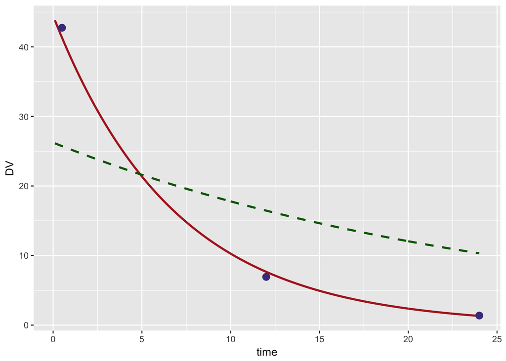

```r
ggplot() +
  geom_line(data=pred, aes(time,DV),col="firebrick", lwd=1) +
  geom_line(data=initial,aes(time,DV), lty=2, col="darkgreen", lwd=1) +
  geom_point(data=data %>% filter(evid==0), aes(time,DV), col="darkslateblue",size=3)
```